# Homework #9

Akash Setti, Anuraag Pujari, Gauthaman Sethupathy, Siddharthan Prakash

4/12/2022

```r
df <- read.csv("https://raw.githubusercontent.com/fivethirtyeight/data/master/avengers/avengers.csv", stringsAsFactors = FALSE)
head(df)
```

```
##                                                       URL
## 1           http://marvel.wikia.com/Henry_Pym_(Earth-616)
## 2      http://marvel.wikia.com/Janet_van_Dyne_(Earth-616)
## 3       http://marvel.wikia.com/Anthony_Stark_(Earth-616)
## 4 http://marvel.wikia.com/Robert_Bruce_Banner_(Earth-616)
## 5        http://marvel.wikia.com/Thor_Odinson_(Earth-616)
## 6       http://marvel.wikia.com/Richard_Jones_(Earth-616)
##                    Name.Alias Appearances Current. Gender Probationary.Introl
## 1   Henry Jonathan "Hank" Pym        1269      YES   MALE
## 2              Janet van Dyne        1165      YES FEMALE
## 3 Anthony Edward "Tony" Stark        3068      YES   MALE
## 4         Robert Bruce Banner        2089      YES   MALE
## 5                Thor Odinson        2402      YES   MALE
## 6      Richard Milhouse Jones         612      YES   MALE
##   Full.Reserve.Avengers.Intro Year Years.since.joining Honorary Death1 Return1
```

[output cut: 20 more lines]

```r
# For Deaths
df$Death_Time <- df
df <- df %>%
  mutate(Death_Time = case_when(
    endsWith(Death5, "YES") ~ "5",
    endsWith(Death4, "YES") ~ "4",
    endsWith(Death3, "YES") ~ "3",
    endsWith(Death2, "YES") ~ "2",
    endsWith(Death1, "YES") ~ "1",
    ))
df$Deaths <- df
df <- df %>%
  mutate(Deaths = case_when(
    endsWith(Death_Time, "1") ~ "Yes",
    endsWith(Death_Time, "2") ~ "Yes",
    endsWith(Death_Time, "3") ~ "Yes",
    endsWith(Death_Time, "4") ~ "Yes",
    endsWith(Death_Time, "5") ~ "Yes",
    ))
df<- df %>%
  mutate_at(vars("Deaths"), ~replace_na(., "No"))


# For Return
df$Return_Time <- df
df <- df %>%
  mutate(Return_Time = case_when(
    endsWith(Return5, "YES") ~ "5",
    endsWith(Return4, "YES") ~ "4",
    endsWith(Return3, "YES") ~ "3",
    endsWith(Return2, "YES") ~ "2",
    endsWith(Return1, "YES") ~ "1",
    ))
df$Returns <- df
df <- df %>%
  mutate(Returns = case_when(
    endsWith(Return_Time, "1") ~ "Yes",
    endsWith(Return_Time, "2") ~ "Yes",
    endsWith(Return_Time, "3") ~ "Yes",
    endsWith(Return_Time, "4") ~ "Yes",
    endsWith(Return_Time, "5") ~ "Yes",
    ))

df <- df %>%
  mutate_at(vars("Returns"), ~replace_na(., "No"))

df <- subset(df, select = -c(Death1: Return5))
df
```

```
##                                                                     URL
## 1                         http://marvel.wikia.com/Henry_Pym_(Earth-616)
## 2                    http://marvel.wikia.com/Janet_van_Dyne_(Earth-616)
## 3                     http://marvel.wikia.com/Anthony_Stark_(Earth-616)
## 4               http://marvel.wikia.com/Robert_Bruce_Banner_(Earth-616)
## 5                      http://marvel.wikia.com/Thor_Odinson_(Earth-616)
## 6                     http://marvel.wikia.com/Richard_Jones_(Earth-616)
## 7                     http://marvel.wikia.com/Steven_Rogers_(Earth-616)
## 8                      http://marvel.wikia.com/Clint_Barton_(Earth-616)
## 9                   http://marvel.wikia.com/Pietro_Maximoff_(Earth-616)
## 10                   http://marvel.wikia.com/Wanda_Maximoff_(Earth-616)
## 11                 http://marvel.wikia.com/Jacques_Duquesne_(Earth-616)
## 12                         http://marvel.wikia.com/Hercules_(Earth-616)
## 13                       http://marvel.wikia.com/T%27Challa_(Earth-616)
## 14                           http://marvel.wikia.com/Vision_(Earth-616)
```

[output cut: 1029 more lines]

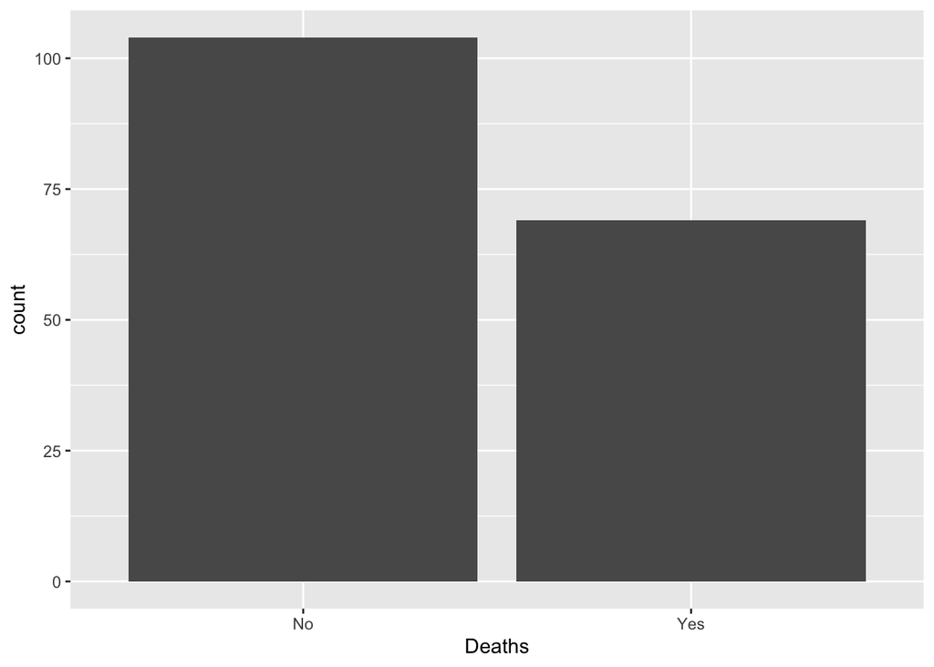

```r
df %>%
  ggplot(aes(x = Deaths)) +
  geom_bar()
```

Siddharthan: The plot above shows that out of the 173 avengers, there have been between 60 and 75 avengers that have at least died once. This agrees with the analysis in FiveThirtyEight where they found 69 had died at least one time after they joined the team. (Sidarthan Prakash)

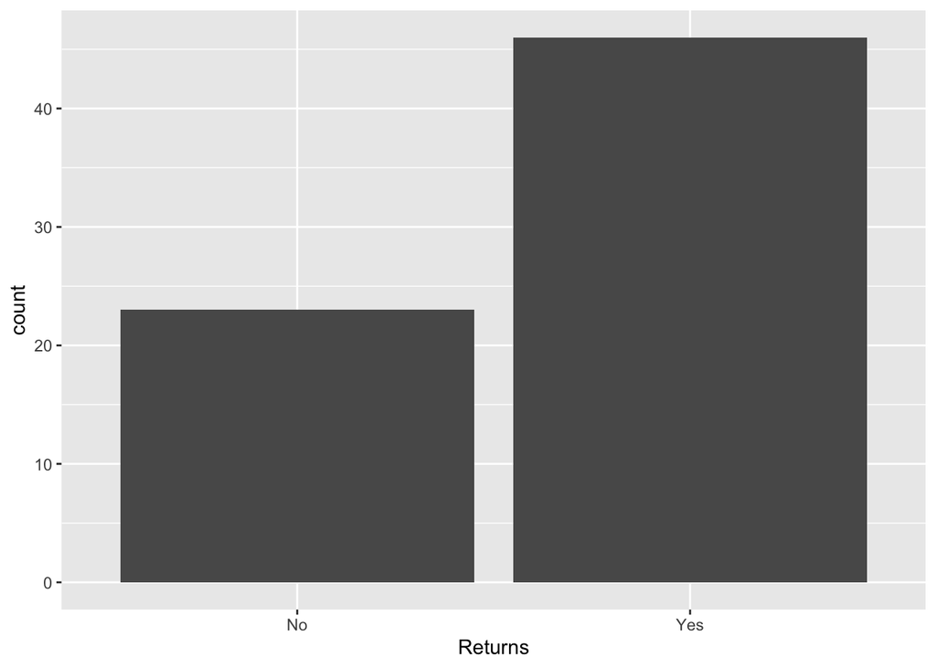

```r
df2 <- df[df$Deaths == "Yes",]
df2 %>%
  ggplot(aes(x = Returns)) +
  geom_bar()
```

```r
df3 <- df2 %>% filter(Death_Time %in% c("2", "3"))
table(df3$Return_Time)
```

```
##
## 1 2
## 8 7
```

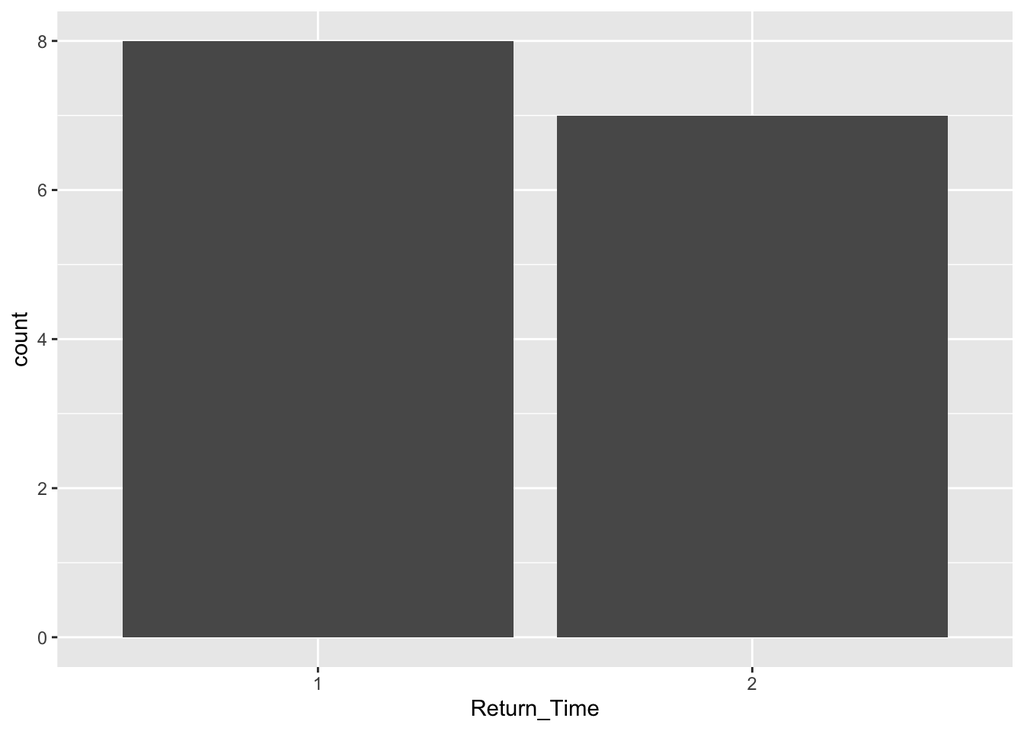

```r
df3 %>%
  ggplot(aes(x = Return_Time)) +
  geom_bar()
```

Akash: The article analysis said that during the second and third death 50 percent of avengers returned. I filtered the data based from the preexisting data to just include avengers who died 2-3 times. I am looking at the amount of times they returned during their second and third death. I was able to see that out of 15 entries, they returned 7 times. So the statement holds(7/15), “only a 50 percent chance they recovered from a second or third death.”

```r
# table(df$Return_Time)
new_df <- df %>% filter(Name.Alias %in% c('Anthony Edward "Tony" Stark', "Robert Bruce Banner", "Thor Odinson", "Steven Rogers", "Clinton Francis Barton", "Natalia Alianovna Romanova", "Pietro Maximoff", "Wanda Maximoff", "Victor Shade (alias)"))
new_df
```

```
##                                                       URL
## 1       http://marvel.wikia.com/Anthony_Stark_(Earth-616)
## 2 http://marvel.wikia.com/Robert_Bruce_Banner_(Earth-616)
## 3        http://marvel.wikia.com/Thor_Odinson_(Earth-616)
## 4       http://marvel.wikia.com/Steven_Rogers_(Earth-616)
## 5        http://marvel.wikia.com/Clint_Barton_(Earth-616)
## 6     http://marvel.wikia.com/Pietro_Maximoff_(Earth-616)
## 7      http://marvel.wikia.com/Wanda_Maximoff_(Earth-616)
## 8              http://marvel.wikia.com/Vision_(Earth-616)
## 9   http://marvel.wikia.com/Natalia_Romanova_(Earth-616)#
##                    Name.Alias Appearances Current. Gender Probationary.Introl
## 1 Anthony Edward "Tony" Stark        3068      YES   MALE
## 2         Robert Bruce Banner        2089      YES   MALE
## 3                Thor Odinson        2402      YES   MALE
## 4               Steven Rogers        3458      YES   MALE
```

[output cut: 35 more lines]

Anuraag: I confirmed with the article that the 9 avengers shown in the article died at least once. I filtered the data, and created a data frame that just incorporates those Avengers. In the death column we can see that it is all yes’s.

Github repo link: https://github.com/asetti2002/DS202Homework9